# GLMMs: worked examples

### Fitting

First, fit the model in each framework.

#### lme4::glmer

(The syntax `pkg::fun` refers in general to a function `fun` in the R package `pkg`.)

```r
cmod_lme4_L <- glmer(predation~ttt+(1|block),data=culcita_dat,
               family=binomial)
```

Take a quick look at the results:

```r
print(summary(cmod_lme4_L),correlation=FALSE)
```

```
## Generalized linear mixed model fit by maximum likelihood (Laplace
##   Approximation) [glmerMod]
##  Family: binomial  ( logit )
## Formula: predation ~ ttt + (1 | block)
##    Data: culcita_dat
##
##      AIC      BIC   logLik deviance df.resid
##     70.7     82.6    -30.4     60.7       75
##
## Scaled residuals:
##     Min      1Q  Median      3Q     Max
## -23.208  -0.173   0.098   0.298   0.894
##
## Random effects:
##  Groups Name        Variance Std.Dev.
##  block  (Intercept) 11.8     3.44
## Number of obs: 80, groups:  block, 10
##
## Fixed effects:
##             Estimate Std. Error z value Pr(>|z|)
## (Intercept)     5.10       1.81    2.81   0.0049 **
## tttcrabs       -3.84       1.46   -2.62   0.0087 **
## tttshrimp      -4.43       1.55   -2.86   0.0043 **
## tttboth        -5.60       1.72   -3.25   0.0012 **
## ---
## Signif. codes:  0 '***' 0.001 '**' 0.01 '*' 0.05 '.' 0.1 ' ' 1
```

It would be nice to fit the model with a random effect of treatments across blocks as well, but it takes a long time and warns that it has failed to converge …

```r
cmod_lme4_block <- update(cmod_lme4_L,.~ttt+(ttt|block))
```

```
## Warning: failure to converge in 10000 evaluations
## Warning: Model failed to converge with max|relative grad| = 122.885 (tol = 0.001, component 2)
## Warning: Model is nearly unidentifiable: large eigenvalue ratio
##  - Rescale variables?
```

(we could extend the maximum number of iterations by using (e.g.) `control=glmerControl(optCtrl=list(maxfun=1e5))`, but it probably wouldn't help). (When you use `update()` you normally specify which variables to add (e.g. `.~.+new_var`) or subtract (`.~.-dropped_var`). Here I replaced the entire right-hand side of the formula: I might have been able to replace the intercept-only random effect with a random effect of treatment by subtracting and adding, i.e. `.~.-(1|block)+(ttt|block)`, but I wasn't sure it would work …)

If we examine the parameter estimates from this fit, we see various additional indications of trouble. The `crab` parameter and several of the variance-covariance parameters are very large and some of the variance-covariance parameters are very strongly correlated with each other, both indications that the model is overfitted:

```r
fixef(cmod_lme4_block)
```

```
## (Intercept)    tttcrabs   tttshrimp     tttboth
##       2.221      20.547      -1.377      -4.728
```

```r
VarCorr(cmod_lme4_block)
```

```
##  Groups Name        Std.Dev. Corr
##  block  (Intercept)  0.227
##         tttcrabs    53.559   -0.30
##         tttshrimp    4.385   -0.21  0.99
##         tttboth     23.482   -0.19  0.99  1.00
```

We can also use model comparison to see that it's not worth adding the extra terms:

```r
AICtab(cmod_lme4_L,cmod_lme4_block,nobs=nrow(culcita_dat))
```

```
##                 dAIC df
## cmod_lme4_L      0.0 5
## cmod_lme4_block  0.4 14
```

(If we use AICc instead of AIC `cmod_lme4_block` does even worse, by 6 AICc units …)

Fitting with Gauss-Hermite quadrature:

```r
cmod_lme4_AGQ10 <- update(cmod_lme4_L,nAGQ=10)
```

The next plot (showing the values of each parameter as a function of the number of quadrature points) shows that using more quadrature points does have some effect, but on an absolute scale the parameters don't vary much: probably the biggest effect is in the estimated among-block standard deviation, increasing irregularly from 3.44 for the Laplace approximation (\( n=1 \)) to an asymptote of 3.51.

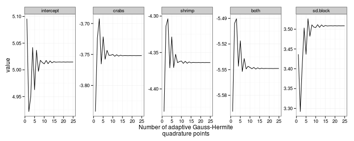

#### glmmADMB

The only difference in moving from `lme4` to `glmmADMB` is that you have to express the `family` argument as a quoted string (i.e., `family="binomial"` rather than `family=binomial`):

```r
cmod_gA_L <- glmmadmb(predation~ttt+(1|block),data=culcita_dat,
               family="binomial")
```

The `summary()` for `glmmADMB` is nearly identical.

```r
summary(cmod_gA_L)
```

```
##
## Call:
## glmmadmb(formula = predation ~ ttt + (1 | block), data = culcita_dat,
##     family = "binomial")
##
## AIC: 70.7
##
## Coefficients:
##             Estimate Std. Error z value Pr(>|z|)
## (Intercept)     5.10       1.81    2.81   0.0049 **
## tttcrabs       -3.84       1.47   -2.62   0.0087 **
## tttshrimp      -4.43       1.55   -2.86   0.0043 **
## tttboth        -5.60       1.73   -3.25   0.0012 **
## ---
## Signif. codes:  0 '***' 0.001 '**' 0.01 '*' 0.05 '.' 0.1 ' ' 1
##
## Number of observations: total=80, block=10
## Random effect variance(s):
## Group=block
##             Variance StdDev
## (Intercept)    11.89  3.448
##
##
## Log-likelihood: -30.35
```

#### MCMCglmm

The `MCMCglmm` random effect specification is a little different from `glmer` and `glmmadmb`: other differences include

First attempts, first with everything set to the default and then with a longer run: ⌛ (60 seconds: *in general I will use this hourglass icon to indicate code that might take a long time to run – you might want to skip running these chunks.*)

```r
cmod_MG0 <- MCMCglmm(predation~ttt,
                     random=~block,data=culcita_dat,
                     family="categorical",
                     verbose=FALSE)
cmod_MG1 <- MCMCglmm(predation~ttt,
                    random=~block,data=culcita_dat,
                    family="categorical",verbose=FALSE,
                    nitt=5e5,burnin=5e4,thin=100)
```

As we will see below, simply running for longer won't fix everything. Instead, we set stronger/better priors as described above:

```r
prior.c <- list(R=list(V=1,fix=1),
                G=list(G1=list(V=1, nu=1, alpha.mu=0, alpha.V=1000)))
cmod_MG <- MCMCglmm(predation~ttt,
                    random=~block,data=culcita_dat,
                     slice=TRUE, ## slice sampling: for binary trials
                                 ## with independent residuals
                     pl=TRUE,    ## save posterior distributions of latent
                                 ## variables (= conditional modes)
                    prior=prior.c,
                    family="categorical",verbose=FALSE,
                    nitt=13000*10,burnin=3000*10,thin=5*10)
```

```r
(cmod_MGsum <- summary(cmod_MG))
```

```
##
##  Iterations = 30001:129951
##  Thinning interval  = 50
##  Sample size  = 2000
##
##  DIC: 52.33
##
##  G-structure:  ~block
##
##       post.mean l-95% CI u-95% CI eff.samp
## block      59.3     5.03      174      106
##
##  R-structure:  ~units
##
##       post.mean l-95% CI u-95% CI eff.samp
## units         1        1        1        0
##
##  Location effects: predation ~ ttt
##
##             post.mean l-95% CI u-95% CI eff.samp  pMCMC
## (Intercept)      7.28     1.84    13.84      464  0.012 *
## tttcrabs        -5.11    -8.96    -1.58      670  0.002 **
## tttshrimp       -6.00   -10.53    -2.50      387 <5e-04 ***
## tttboth         -7.80   -12.56    -3.76      353 <5e-04 ***
## ---
## Signif. codes:  0 '***' 0.001 '**' 0.01 '*' 0.05 '.' 0.1 ' ' 1
```

Take note of the `eff.samp` columns in the summary output, which describe the size of the sample we have taken from the posterior distribution corrected for autocorrelation; values much smaller than the nominal sample size (listed in the third line of the summary) indicate poor mixing.

### Diagnostics and model summaries

#### lme4

Diagnostic plots:

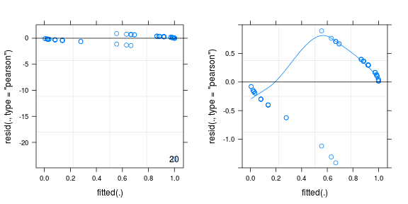

```r
p1 <- plot(cmod_lme4_L,id=0.05,idLabels=~.obs)
p2 <- plot(cmod_lme4_L,ylim=c(-1.5,1),type=c("p","smooth"))
grid.arrange(p1,p2,nrow=1)
```

The only thing that the default (left-hand) diagnostic plot tells us is that observation #20 has a (very) extreme residual (we use `idLabels=~.obs` to get outliers labelled by their observation number; otherwise, by default, they are labelled by their groups); if we use `ylim=c(-1.5,1)` to limit the \( y \)-range, we get (on the right) the usual not-very-informative residuals plot expected from binary data.

### Digression: complete separation

If we exclude observation 20, we see the symptoms of [complete separation](http://www.ats.ucla.edu/stat/mult_pkg/faq/general/complete_separation_logit_models.htm) (e.g., parameter values with \( |\beta|>10 \), huge Wald confidence intervals and large Wald \( p \)-values).

We refit the model with the new data …

```r
newdat <- subset(culcita_dat,
                 abs(resid(cmod_lme4_L,"pearson"))<10)
cmod_lme4_L2 <- update(cmod_lme4_L,data=newdat)
```

We can use `bglmer` from the `blme` package to impose zero-mean Normal priors on the fixed effects (a 4 \( \times \) 4 diagonal matrix with diagonal elements equal to 9, for variances of 9 or standard deviations of 3), or add a `B` element to the priors list for `MCMCglmm` to specify the same priors:

```r
cmod_blme_L2 <- bglmer(predation~ttt+(1|block),data=newdat,
                       family=binomial,
                       fixef.prior = normal(cov = diag(9,4)))
cmod_MG2 <- MCMCglmm(predation~ttt,
                    random=~block,data=newdat,
                    family="categorical",verbose=FALSE,
                    nitt=13e4,burnin=3e4,thin=50,
                    prior=c(prior.c,
                        list(B=list(mu=rep(0,4),
                           V=diag(9,4)))))
```

Both methods of constraining the parameters give similar results:

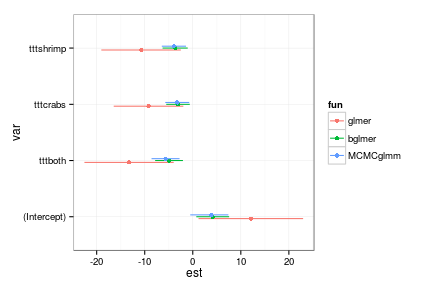

There are other packages in R (`brglm`, `logistf`) that can handle completely separated data, but they only apply to logistic regression, and they cannot simultaneously incorporate random effects (Pasch *et al.*, *American Naturalist* 2013 used `brglm` to handle completely separated data, arguing that random effects were not very important in their system.)

(*End of digression*)

We can do a little bit better with boxplots grouped by treatment (again limiting the range to exclude the outlier).

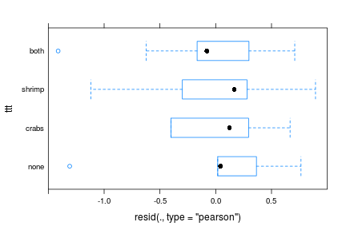

```r
plot(cmod_lme4_L,ttt~resid(.,type="pearson"),xlim=c(-1.5,1))
```

Check the random effects:

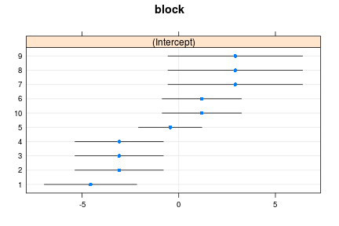

```r
dotplot(ranef(cmod_lme4_L,condVar=TRUE))
```

There are only a few unique values of the random effects because there are only a few possible configurations per block of predation/no-predation in each treatment.

It's worth checking `methods(class="merMod")` to see all the things you can do with the fit (some of them may be a bit obscure …) The most important are:

- `fixef()` to extract the vector of fixed-effect parameters (confusingly, `coef()` – which is the accessor method for finding coefficients for most other models in R – gives a matrix showing the estimated coefficients for each block (incorporating the random effects), which I don't find useful very often)
- `coef(summary(.))` to extract just the table of estimates with standard errors, \( z \) values, and \( p \)-values
- `VarCorr()` to extract the estimates of the random effect variances and covariances. (Use `unlist(VarCorr(.))` if you want the variances as a vector.)
- `ranef()` to extract estimates of the random effects, and `dotplot(ranef(.,condVar=TRUE))` or `qqmath(ranef(.,condVar=TRUE))` to explore them graphically
- `plot()` for diagnostic plots
- `AIC()`, `anova()`, `drop1()`, `confint()`, `profile()` for various statistical tests
- `predict()` for predictions; `simulate()` for simulations based on the model

#### glmmADMB

The methods and diagnostics for `glmmADMB` are similar, although not quite as well developed. You can still create the same kinds of diagnostic plots (I have done this one with `ggplot2` rather than `lattice`):

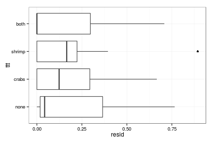

```r
augDat <- data.frame(culcita_dat,resid=residuals(cmod_gA_L,type="pearson"),
                     fitted=fitted(cmod_gA_L))
ggplot(augDat,aes(x=ttt,y=resid))+geom_boxplot()+coord_flip()
```

#### MCMCglmm

Within an `MCMCglmm` fit the chains are stored in two separate matrices (`mcmc` objects, actually, but these can be treated a lot like matrices) called `Sol` (fixed effects) and `VCV` (variances and covariances). (Random effects are not saved unless you set `pr=TRUE`.)

```r
allChains <- as.mcmc(cbind(cmod_MG0$Sol,cmod_MG0$VCV))
```

The trace plots for the default parameters:

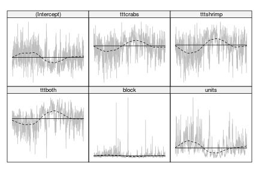

```r
plotTrace(allChains)
```

Running longer:

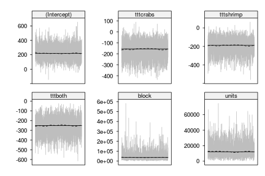

```r
allChains2 <- as.mcmc(cbind(cmod_MG1$Sol,cmod_MG1$VCV))
plotTrace(allChains2,axes=TRUE,las=1)
```

This looks OK at first glance, but the magnitudes of the parameters (suppressed by default from the `tracePlot` results since we're initially interested only in the pattern, not the magnitude, of the parameters) suggest a problem: the values of the fixed-effect parameters are in the hundreds, when any values with \( |\beta|>10 \) suggest a problem.

The fundamental problem here is that, for both technical and philosophical reasons, `MCMCglmm` always adds an observation-level variance (referred to in `MCMCglmm` as the “R-structure”, for “residual structure”), corresponding to an overdispersion term. For binary data, \[ \text{logit}(p_i) = m_i + \epsilon_i \] where \( \epsilon_i \sim N(0,\sigma^2) \) then the *expected value* of \( p_i \) is the average of \( \text{logistic}(m_i+\epsilon_i) \). This is a nonlinear average, and so the mean of \( p_i \) is *not* equal to \( \text{logistic}(m_i) \) (this phenomenon is called [Jensen's inequality](http://en.wikipedia.org/wiki/Jensen%27s_inequality); Ruel and Ayres 1999 give an ecologist-friendly explanation). If \( \ell(x)=1/(1+\exp(-x)) \) is the logistic function then the mean of \( p_i \) is approximately \[ \overline{p_i} \approx \ell(m_i) + \left.\frac{d^2\ell}{dx^2}\right|_{x=m_i} \cdot \sigma^2/2 \]

We won't bother to show the math of \( d^2\ell(x)/dx^2 \) here: suffice it to say that this term varies from about +0.1 to -0.1 depending on the baseline value \( m_i \), so that the estimates of \( m_i \) and the observation-level variance \( \sigma^2 \) are confounded:

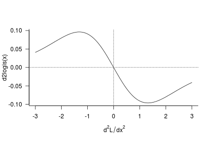

To deal with the confounding between these variables, we fix the value of \( \sigma^2_R \) as described above. The results:

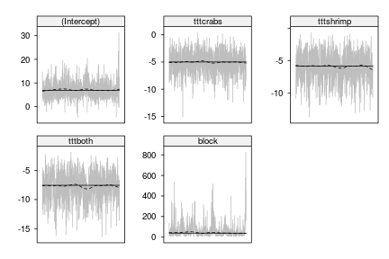

```r
allChains3 <- as.mcmc(cbind(cmod_MG$Sol,cmod_MG$VCV))
## units variance is fixed to 1 anyway, we don't need
## to examine it
allChains3 <- allChains3[,colnames(allChains3)!="units"]
plotTrace(allChains3,axes=TRUE,las=1)
```

Now the magnitudes of the parameters look a little bit more sensible. The chains for the variances are a little bit “spiky” because the posterior densities have long right tails, so it can be helpful to look at them on a log scale (it's easier to see the details when the distribution is symmetric):

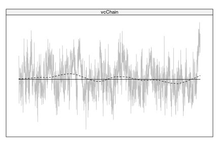

```r
vcChain <- log10(cmod_MG$VCV)[,1]
plotTrace(vcChain)
```

We have one more thing to worry about. If we extract `cmod_MG$Liab` (the conditional modes/latent variables) and plot their histogram:

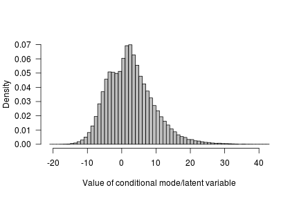

Some of the latent variables are larger than 20. The likelihood of the linear predictor is essentially flat from \( [20,\infty] \). If this happens for all observations belonging to a single term (fixed or random) then there is nothing constraining that term except the prior (\( B \)) or for random effects the posterior variance. Consequently issues can arise, without suitable prior or hyper prior specifications – this suggests that we might want to consider using the slightly stronger priors on \( B \) specified above when we were trying to deal with complete separation.

In order to compare the estimates we get from `MCMCglmm` with the other models – which do not incorporate an observation-level random effect – we Rescale block variance to what it would be had we set the units variance to zero, and overlay `lmer` estimate:

```r
## see eqs. 2.13, 2.14 of the MCMCglmm 'CourseNotes' vignette
## for further information & references:
c2 <- ((16 * sqrt(3))/(15 * pi))^2
cmod_MGsc <- cmod_MG
cmod_MGsc$VCV[,"block"] <-
  cmod_MGsc$VCV[,"block"]/(1+c2*cmod_MGsc$VCV[,"units"])
cmod_MGsc$Sol[] <- cmod_MGsc$Sol/sqrt(1+c2*cmod_MGsc$VCV[,"units"])
cmod_MGsc$VCV[,1] <- sqrt(cmod_MGsc$VCV[,1])
```

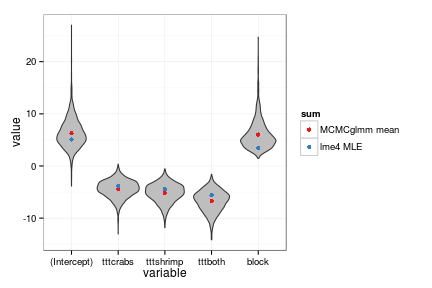

The modes of the `MCMCglmm` results (the fattest part of the “violins”) agree well with the `lme4` MLEs, for the most part: the `lme4` estimate of the among-block standard deviation is a bit lower than the `MCMCglmm` estimate. (When we display the overall parameter comparison below, we will show the MCMCglmm means instead.)

### Inference

We get the values of the parameters and the (Wald) standard errors, \( Z \)- and \( p \)-values (for `glmer()` and `glmmADMB()`), or the (quantile-based) credible intervals and “pMCMC” values from the `summary()` output, as shown above.

If we want more accurate profile confidence interval, parametric bootstrap, or MCMC-based confidence intervals for `glmer()`- or `glmmADMB()`-based analyses, we use `confint()`:

⌛ Compute profile confidence intervals:

```r
cmod_lme4_L_CI_prof <- confint(cmod_lme4_L)
cmod_lme4_L_CI_quad <- confint(cmod_lme4_L,method="Wald")
cmod_lme4_L_CI_boot <- confint(cmod_lme4_L,method="boot")
```

The parameter estimates and confidence intervals are reasonably consistent across packages and algorithms.

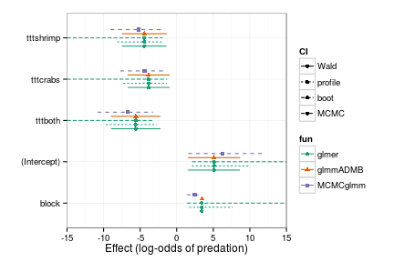

### Model comparison/hypothesis testing

The summary of the model gives us crude (Wald) estimates of the \( p \)-values for each individual parameter:

```r
coef(summary(cmod_lme4_L))
```

```
##             Estimate Std. Error z value Pr(>|z|)
## (Intercept)    5.096      1.811   2.814 0.004899
## tttcrabs      -3.842      1.465  -2.623 0.008710
## tttshrimp     -4.431      1.551  -2.856 0.004290
## tttboth       -5.599      1.724  -3.247 0.001165
```

We can get the overall \( p \)-value for the effect of treatment and use `anova()` to do a likelihood ratio test:

```r
cmod_lme4_0 <- update(cmod_lme4_L,.~.-ttt)
anova(cmod_lme4_L,cmod_lme4_0)
```

```
## Data: culcita_dat
## Models:
## cmod_lme4_0: predation ~ (1 | block)
## cmod_lme4_L: predation ~ ttt + (1 | block)
##             Df  AIC  BIC logLik deviance Chisq Chi Df Pr(>Chisq)
## cmod_lme4_0  2 86.2 91.0  -41.1     82.2
## cmod_lme4_L  5 70.7 82.6  -30.4     60.7  21.5      3    8.3e-05 ***
## ---
## Signif. codes:  0 '***' 0.001 '**' 0.01 '*' 0.05 '.' 0.1 ' ' 1
```

We could also use `drop1(cmod_lme4_L,test="Chisq")` to refit the reduced model automatically (helpful if we have a more complex model with more separate fixed effects to test).

We can also get parametric bootstrap confidence intervals (). I initially tried to do this via `PBmodcomp(cmod_lme4_L,cmod_lme4_0,nsim=400)`, but failed when one of the model-refitting steps produced an error. Instead, I defined my own parametric bootstrap function which tests to make sure that neither of the refitting steps failed:

```r
PBsimfun <- function(m0,m1,x=NULL) {
  if (is.null(x)) x <- simulate(m0)
  m0r <- try(refit(m0,x[[1]]),silent=TRUE)
  if (inherits(m0r,"try-error")) return(NA)
  m1r <- try(refit(m1,x[[1]]),silent=TRUE)
  if (inherits(m1r,"try-error")) return(NA)
    c(-2*(logLik(m0r)-logLik(m1r)))
}
```

⌛

```r
set.seed(101)
PBrefdist <- replicate(400,PBsimfun(cmod_lme4_0,cmod_lme4_L))
```

Out of 400 replicates, 4 are `NA` (the refitting failed somehow), and 1 is <0 by a tiny amount (numerical inaccuracy in the fitting). It is also appropriate to add the observed value of the difference in \( -2 \log(L) \) to the reference distribution:

```r
obsval <- -2*(logLik(cmod_lme4_0)-logLik(cmod_lme4_L))
PBrefdist <- c(na.omit(pmax(PBrefdist,0)),obsval)
```

The histogram looks pretty close to the expected \( \chi^2_3 \) distribution for the likelihood ratio test (3 degrees of freedom because we are comparing a model with 4 vs. 1 fixed-effect parameters):

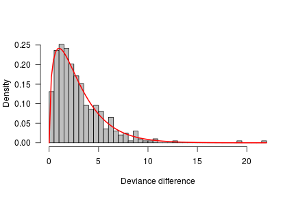

However, we would probably prefer a real \( p \)-value, which we get by computing the fraction of values in the reference distribution >= the observed value (we can use `mean(ref>obs)` as a shortcut to compute this proportion). Since the observed value is included in the reference distribution, the \( p \)-value can never be less than \( 1/(\mbox{nsim}+1) \), which is its value in this case:

```r
mean(PBrefdist>=obsval)
```

```
## [1] 0.002519
```

If we want to use parametric bootstrapping to test a different hypothesis, either based on the assumption that a single parameter is zero or based on some particular *contrast* among the treatments (e.g. that the effect of two symbionts is equal to the effect of either symbiont alone), we have to set up our own dummy variables rather than relying on R's automatic handling of categorical (factor) variables.

Suppose we want to compare the effect of a single symbiont of either kind to the effect of two symbionts (i.e., the average of crabs and shrimp). This is a bit more challenging than testing the overall effect of treatment. First we have to set up an appropriate *contrast* to partition the effects of treatment. In this case we change the default treatment contrasts (control, control vs. crab, control vs. shrimp, control vs. both) to test (i) control, (ii) any symbionts vs no symbionts, (iii) crabs alone vs shrimp alone, (iv) one symbiont vs two symbionts.

```r
invcontr <- matrix(c(1,0,0,0,
                  -1,1/3,1/3,1/3,
                   0,-1,1,0,
                   0,-1/2,-1/2,1),
                   byrow=TRUE,ncol=4,
                   dimnames=list(c("none","symbiont",
                   "C_vs_S","1_vs_2"),
              levels(culcita_dat$ttt)))
cmat0 <- solve(invcontr)[,-1]
```

Because we will want to do a parametric bootstrap test of one particular contrast, we will need to be able to exclude that variable from the model. We do this by setting up the model matrix explicitly and using its columns explicitly as *numeric* dummy variables:

```r
X <- model.matrix(~ttt,
                  data=culcita_dat,
                  contrasts=list(ttt=cmat0))
culcita_dat2 <- with(culcita_dat,data.frame(block,predation,
                                            X[,-1]))
cmod_lme4C_L <- glmer(predation~tttsymbiont+
                        tttC_vs_S+ttt1_vs_2+
                        (1|block),data=culcita_dat2,
                      family=binomial)
## fit reduced model as well
cmod_lme4C_L0 <- update(cmod_lme4C_L,.~.-ttt1_vs_2)
```

Now we do the parametric bootstrap comparison (⌛!):

```r
set.seed(101)
PBrefdist2 <- replicate(400,PBsimfun(cmod_lme4C_L0,cmod_lme4C_L))
```

And compute the \( p \)-value by comparing against the observed value as above:

```r
obsval2 <- -2*(logLik(cmod_lme4C_L0)-logLik(cmod_lme4C_L))
PBrefdist2 <- c(na.omit(pmax(PBrefdist2,0)),obsval2)
mean(PBrefdist2>=obsval2)
```

```
## [1] 0.1544
```

Ironically, after all that computational effort this \( p \)-value is nearly identical to the value from the Wald test:

```r
coef(summary(cmod_lme4C_L))
```

```
##             Estimate Std. Error z value Pr(>|z|)
## (Intercept)   5.0957      1.811  2.8136 0.004899
## tttsymbiont  -4.6241      1.440 -3.2106 0.001325
## tttC_vs_S    -0.5888      1.099 -0.5357 0.592141
## ttt1_vs_2    -1.4624      1.023 -1.4290 0.153012
```

### Prediction

Getting predicted values from an `lme4` model (or an `MCMCglmm` model) is fairly straightforward: in this case by specifying `re.form=NA` we're saying that we want the *population-level* prediction, i.e. setting the random effects to zero and getting a prediction for an average (or unknown) block:

```r
pframe <- data.frame(ttt=factor(levels(culcita_dat$ttt),
                                levels=levels(culcita_dat$ttt)))
cpred1 <- predict(cmod_lme4_L,re.form=NA,newdata=pframe,type="response")
```

Computing confidence intervals on the predicted values is relatively easy *if* we're willing to completely ignore the random effects, and the uncertainty of the random effects. Here is a generic function that extracts the relevant bits from a fitted model and returns the confidence intervals for predictions:

```r
easyPredCI <- function(model,newdata,alpha=0.05) {
    ## baseline prediction, on the linear predictor (logit) scale:
    pred0 <- predict(model,re.form=NA,newdata=newdata)
    ## fixed-effects model matrix for new data
    X <- model.matrix(formula(model,fixed.only=TRUE)[-2],
                   newdata)
    beta <- fixef(model) ## fixed-effects coefficients
    V <- vcov(model)     ## variance-covariance matrix of beta
    pred.se <- sqrt(diag(X %*% V %*% t(X))) ## std errors of predictions
    ## inverse-link (logistic) function: could also use plogis()
    linkinv <- model@resp$family$linkinv
    ## construct 95% Normal CIs on the link scale and
    ##  transform back to the response (probability) scale:
    crit <- -qnorm(alpha/2)
    linkinv(cbind(lwr=pred0-crit*pred.se,
                  upr=pred0+crit*pred.se))
}
cpred1.CI <- easyPredCI(cmod_lme4_L,pframe)
```

We can also get parametric bootstrap predictions by resampling, refitting, and re-predicting many times and computing the 95% quantiles of the predictions: ⌛

```r
set.seed(101)
bb <- bootMer(cmod_lme4_L,
              FUN=function(x)
              predict(x,re.form=NA,newdata=pframe,type="response"),
              nsim=500)
cpredboot1.CI <- t(sapply(1:4,
       function(i)
         boot.ci(bb,type="perc",index=i)$percent[4:5]))
## or: t(apply(bb$t,2,quantile,c(0.025,0.975),na.rm=TRUE))
```

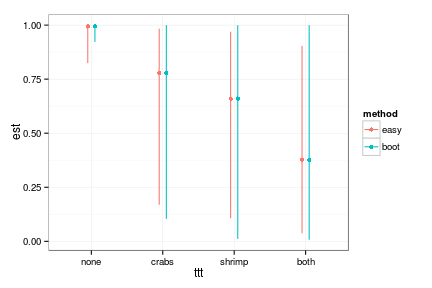

The confidence intervals from the “easy” approach and the bootstrap approach are similar in this case. The bootstrap CIs are sometimes narrower (the lower CI for the predation probability of undefended corals is higher for the bootstrap than the “easy” CI) and sometimes larger (the upper bootstrap CIs for all of the other treatments extends all the way up to 1.0).

## Gopher tortoise

The data are from Ozgul *et al.* 2009s, Upper respiratory tract disease, force of infection, and effects on survival of gopher tortoises. *Ecological Applications* 19(3), 786-798.

### Data

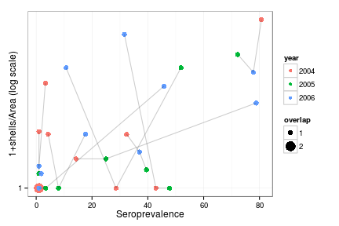

```r
load("gopherdat2.RData")
(gplot1 <- ggplot(Gdat,aes(x=prev,y=1+shells/Area))+
    stat_sum(aes(colour=factor(year),
                 size=factor(..n..)))+
    scale_size_discrete(range=c(3,6),name="overlap")+
    scale_y_log10()+
    scale_colour_discrete(name="year")+
    geom_line(aes(group=Site),alpha=0.2)+
    labs(x="Seroprevalence",y="1+shells/Area (log scale)"))
```

There does indeed seem to be a general upward trend in shell density as a function of seroprevalence, but the rest of the plot is pretty messy. Lines connect observations from the same site (in an earlier version I used `geom_text(aes(label=Site))` to label the points by site: this is useful for diagnostic purposes, but ugly).

### Fitting

#### glmer

Fit basic model with a log-linear effect of prevalence, an offset of `log(Area)` (to make the expected number of shells proportional to `Area`), `year` as a fixed categorical effect, and `Site` as a random effect.

```r
gmod_lme4_L <- glmer(shells~prev+offset(log(Area))+factor(year)+(1|Site),
      family=poisson,data=Gdat,
      control=glmerControl(optimizer="bobyqa",
                           check.conv.grad=.makeCC("warning",0.05)))
```

```r
summary(gmod_lme4_L)
```

```
## Generalized linear mixed model fit by maximum likelihood (Laplace
##   Approximation) [glmerMod]
##  Family: poisson  ( log )
## Formula: shells ~ prev + offset(log(Area)) + factor(year) + (1 | Site)
##    Data: Gdat
## Control:
## glmerControl(optimizer = "bobyqa", check.conv.grad = .makeCC("warning",
##     0.05))
##
##      AIC      BIC   logLik deviance df.resid
##     86.3     93.3    -38.2     76.3       25
##
## Scaled residuals:
##    Min     1Q Median     3Q    Max
## -1.015 -0.625 -0.373  0.449  2.459
##
## Random effects:
##  Groups Name        Variance Std.Dev.
##  Site   (Intercept) 0        0
## Number of obs: 30, groups:  Site, 10
##
## Fixed effects:
##                  Estimate Std. Error z value Pr(>|z|)
## (Intercept)      -3.19732    0.27850  -11.48  < 2e-16 ***
## prev              0.02113    0.00431    4.90  9.4e-07 ***
## factor(year)2005 -0.64486    0.35639   -1.81     0.07 .
## factor(year)2006 -0.42876    0.31301   -1.37     0.17
## ---
## Signif. codes:  0 '***' 0.001 '**' 0.01 '*' 0.05 '.' 0.1 ' ' 1
##
## Correlation of Fixed Effects:
##             (Intr) prev   f()2005
## prev        -0.663
## fctr(y)2005 -0.464  0.040
## fctr(y)2006 -0.407 -0.138  0.384
```

This initial summary shows that the site-level variance is exactly zero (corresponding to pooling our data/ignoring the effect of `Site`: if you want to inspect this component of the summary by itself, you can specify `VarCorr(gmod_lme4_L)`). For comparison, we can also explicitly fit (non-mixed) generalized linear models with complete pooling and fixed effects of `Site`, respectively:

```r
gmod_glm <- glm(shells~prev+offset(log(Area))+factor(year),
      family=poisson,data=Gdat)
gmod_glm2 <- glm(shells~prev+offset(log(Area))+factor(year)+factor(Site),
      family=poisson,data=Gdat)
```

Try the fit with Gauss-Hermite quadrature for comparison (perhaps GHQ will estimate a non-zero variance?)

```r
gmod_lme4_agq <- update(gmod_lme4_L,nAGQ=10)
```

No:

```r
VarCorr(gmod_lme4_agq)
```

```
##  Groups Name        Std.Dev.
##  Site   (Intercept) 0
```

```r
AICtab(gmod_glm,gmod_glm2,gmod_lme4_L,logLik=TRUE)
```

```
##             dLogLik dAIC df
## gmod_glm     0.0     0.0 4
## gmod_lme4_L  0.0     2.0 5
## gmod_glm2    3.9    10.2 13
```

(At present `lme4` computes log-likelihood/AIC values for models fitted with GHQ that are not comparable with `glm()` fits or `glmer` Laplace fits, so we skip `gmod_lme4_agq` in this summary.)

The pooled `glm()` and `glmer()` fits have identical log-likelihoods, as expected (when the random-effects variance collapses to 0, `glmer()` is essentially fitting a pooled model): the `glmer()` fit is AIC-penalized for an additional parameter (the among-site variance). The fixed-effect `glm()` fit has a slightly better log-likelihood, but not enough to make up for 9 additional `Site` effect parameters.

Another option in this case is to use `bglmer` from the `blme` package, which sets a weak prior on the variance to push it away from zero:

```r
gmod_blmer_L <- bglmer(shells~prev+offset(log(Area))+factor(year)+(1|Site),
      family=poisson,data=Gdat)
```

```r
gmod_blmer_prof <- confint(gmod_blmer_L)
```

```r
gmod_blmer_bootCI <- confint(gmod_blmer_L,method="boot")
```

Now we do estimate a positive (but small) among-site variance:

```r
VarCorr(gmod_blmer_L)
```

```
##  Groups Name        Std.Dev.
##  Site   (Intercept) 0.301
```

Check for overdispersion: you can do this by hand by computing `sum(residuals(gmod_lme4_L,"pearson")^2))`, but the `gof()` function from the `aods3` package is a handy shortcut (it computes overdispersion based on the deviance (`D` below) and Pearson residuals (`X2`): when they disagree, use the latter:

```r
gof(gmod_lme4_L)
```

```
## D  = 76.34, df = 25, P(>D) = 4.23e-07
## X2 = 22.14, df = 25, P(>X2) = 0.6278
```

The sum of squared Pearson residuals is less than the residual degrees of freedom, so the response is actually underdispersed.

Just for comparison's sake, we'll fit a model with an observation-level random effect (logistic-normal model) anyway:

```r
Gdat$obs <- factor(seq(nrow(Gdat)))
gmod_lme4_L_od <- glmer(shells~prev+offset(log(Area))+factor(year)+(1|Site)+(1|obs),
      family=poisson,data=Gdat)
```

#### glmmADMB

As before, the only thing we have to change for `glmmADMB` is to specify the family in quotation marks (`family="poisson"`):

```r
gmod_gA_L <- glmmadmb(shells~prev+offset(log(Area))+factor(year)+(1|Site),
      family="poisson",data=Gdat)
```

If we want, we have the alternative of fitting a negative-binomial model, either “type 1” (\( \text{Var} = \phi \mu \)) or “type 2” (\( \text{Var} = \mu (1 + \mu/k) \)):

```r
gmod_gA_L_NB2 <- glmmadmb(shells~prev+offset(log(Area))+factor(year)+(1|Site),
      family="nbinom",data=Gdat)
gmod_gA_L_NB1 <- glmmadmb(shells~prev+offset(log(Area))+factor(year)+(1|Site),
      family="nbinom1",data=Gdat)
```

Unsurprisingly (since we know the data are underdispersed), the negative binomial model fits don't decrease the AIC:

```r
AICtab(gmod_gA_L,gmod_gA_L_NB1,gmod_gA_L_NB2)
```

```
##               dAIC df
## gmod_gA_L     0.0  5
## gmod_gA_L_NB1 2.0  6
## gmod_gA_L_NB2 2.1  6
```

#### MCMCglmm

As in the previous example, it turns out we have to run `MCMCglmm` chains for longer, and specify reasonably strong priors, in order to get reasonable results.

Offsets have to be set “by hand” by placing a strong prior on a coefficient of 1 for the offset term; the rest of the fixed-effect parameters get the usual mean of 0 and very large variance.

```r
B.prior <- list(V=diag(5)*1e7, mu=c(0,0,1,0,0))
B.prior$V[3,3] <- 1e-7  ## replace log(area) (offset) variance
```

For the variances, after finding that the default priors were too weak (see below), I initially used priors of the form `list(V=5, nu=5)` to specify fairly strongly that the variance could not be near zero, e.g.:

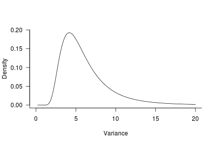

However, Jarrod Hadfield advised me to try parameter-expanded priors instead, as follows:

```r
prior.g <- list(B=B.prior,
                R=list(V=1, nu=0.002),
                G=list(G1=list(V=1, nu=1, alpha.mu=0, alpha.V=1000)))
```

Run with default parameters:

```r
gmod_MG0 <- MCMCglmm(shells~prev+log(Area)+factor(year),
                     random=~Site,
                     family="poisson",data=Gdat,verbose=FALSE,
                     prior=list(B=B.prior))
```

Run for longer:

```r
gmod_MG <- MCMCglmm(shells~prev+log(Area)+factor(year),
                    random=~Site,
                    family="poisson",data=Gdat,verbose=FALSE,
                    prior=list(B=B.prior),
                    nitt=1e5+3e3,thin=1e2)
```

Stronger/better priors (see above):

```r
gmod_MG2 <- MCMCglmm(shells~prev+log(Area)+factor(year),
         random=~Site,
       prior=prior.g,
      family="poisson",data=Gdat,verbose=FALSE,
      nitt=1e5+3e3,thin=1e2)
```

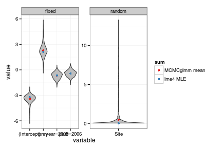